# Bookends 0.4

# Conclusion

**Overview**

Specialist and generalist predators differ in their degree of dependence on prey species with cascading consequences for many aspects of their life history (Korpimaki & Norrdhal 1991, Resano-Mayor et al. 2016). Specialists are efficient hunters of their main prey at the cost of poor success when hunting other species, whereas generalists hunt many species with equal skill (Terraube et al. 2011). A specialist may struggle to compensate with other prey when its main prey becomes scarce, but generalists readily switch to alternate prey (Steenhof & Kochert 1988, Terrabue & Arroyo 2011). Specialists may even be limited in geographic range or habitat use by the presence and abundance of their main prey (Ferrer & Negro 2004, Peers et al. 2003). As a result, specialists depend on a single species and their demographic parameters–such as migration, reproductive success, and survival–vary in synchrony with its abundance (Korpimaki & Norrdhal 1991, Terraube et al. 2011). In contrast, generalists make use of many species but depend on no single one, and their populations are relatively more stable (Hanski et al. 1991, Andersson & Erlinge 1977).

This familiar dichotomy between specialist and generalist species is, of course, an oversimplification. The abundance of a single prey species can be a major driver of demographic parameters, such as reproductive success, for a generalist predator as well as for a specialist (Elmhagen et al. 2000, Resano-Mayor et al. 2006). Within a single species some populations (Salamolard et al. 2000, Roth et al. 2007), or some individuals within a population (Woo et al. 2008), may be more or less specialized. Even a single individual may become more specialized over its lifetime as a result of age and experience (Rutz 2006). Correctly identifying the degree of specialization and understanding its effect on demographic parameters is more than a matter of theory or curiosity: the consequences of specialization can scale up from individuals through populations to entire species, with profound implications for conservation (Ferrer & Negro 2004, Terraube et al. 2011, Resano-Mayor 2016).

In contrast to the spotted owl’s dependence on a few prey species, the northern goshawk is considered a generalist predator and consumes an enormous diversity of prey across its wide geographic range (reviewed in Drennen 2006). I identified **25** different prey species in the diet of goshawks in coastal British Columbia, which is consistent with a generalist foraging strategy. Some goshawk populations appear to be strongly generalist (Salafsky et al. 2007), whereas in others a key prey species is a major driver of productivity, survival, and other demographic parameters (Doyle & Smith 1994, Tornberg et al. 2005). Over 60% of goshawk diet in my study area was composed of tree squirrels (*Tamiasciurus* spp.), which indicates a level of specialization even greater than that of the spotted owl. However, I found no affect of the degree of dietary specialization on goshawk productivity. There are several explanations for this unexpected finding. First, specialists may not be more productive than generalists: some individual goshawks may prefer tree squirrels and consume them disproportionate to their abundance, but both specialists and generalists are equally fit (Woo et al. 2008). Alternately, specialization may be the result of opportunity: all goshawks take tree squirrels proportionate to their abundance, but it is total prey abundance rather than tree squirrel abundance which drives productivity. Finally, as in the spotted owl, prey abundance and diet during the breeding season may not be a lesser driver of productivity than other factors, such as weather or winter prey abundance.

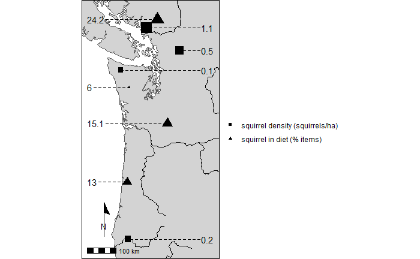

**Directions for future research**

Comparing the northern spotted owl and the northern goshawk highlights significant knowledge gaps regarding goshawk biology. The controversy surrounding the spotted owl, combined with its position at the heart of a major management plan, has made it one of the most-studied birds in the world (Gutierrez et al. 2020). The northern goshawk, although likewise shrouded in controversy, has not received the same level of study. It is also more difficult to generalize research on the widespread, generalist northern goshawk than for the more restricted, relatively specialized spotted owl. As a result, there is a pressing need for detailed, local information on goshawks in the Pacific Northwest, particuarly in coastal British Columbia.

One knowledge gap related to the work I present here is how goshawks respond to variation in prey abundance. Dietary specialization such as goshawks in my study area exhibit may be the result of a preference for the main prey or simply an absence of other options. The hypotheses I propose to explain my results cannot be evaluated without differentiating between these two possibilities. Data on prey abundance is necessary to understand the mechanism of goshawk specialization and whether it is the result of high selectivity for tree squirrels, high abundance of tree squirrels, or some combination of both. This information could in turn be used to evaluate how changes in key prey abundance and total prey abundance influence goshawk demographic parameters, particularly productivity. Without this knowledge it is impossible to fully understand the factors limiting goshawk populations in coastal British Columbia.

A second knowledge gap is how the amount and type of habitat goshawks use for foraging varies with diet and prey abundance. Goshawk home range size varies across their geographic range and goshawks have been observed foraging in diverse habitat types, leading to persistent controversy over how and why goshawks select habitat, particularly foraging habitat (Greenwald et al. 2005, Reynolds et al. 2008). Research on spotted owls indicates that home range size is inversely related to prey abundance and foraging habitat selection varies with the identity of the main prey (Zabel 1995). Diet and prey abundance may likewise explain some of the variation in goshawk habitat use (Kenward 1982, Penteriani et al. 2013). If so, foraging habitat management could only be conducted with knowledge of goshawk diet and recommendations made for one population could be applied to others only with great caution, if at all. Filling this knowledge gap with information specific to coastal British Columbia is crucial and has been identified as a priority by goshawk managers (NGRT 2008, Parks Canada 2018).

To address this crucial knowledge gap, the British Columbia Ministry of Forests, Lands, Natural Resource Operations and Rural Development (FLNRORD) and I conducted a pilot study of foraging habitat use in coastal British Columbia. Between 2018-2020 we tagged 4 male and 9 female goshawks, with only one probable mortality over the course of the study. Captures were conducted during the early breeding season using a dho-gaza trap with a live great-horned owl (*Bubo virginianus*) as a lure (Bloom et al. 2007). Goshawks were fitted with 14-gram geolocator tags (Ecotone Telmetry brand, Harrier model) attached via backpack-style harness. Tags were programmed to take a location point every 15 minutes and to download data to a base station when within range (approximately 100 m from the base). Base stations were placed beneath or above nests and tags checked for proximity to the station every 15 minutes. From each tag we collected between 0 and 73 days of breeding season (20 April - 15 September) data. Of the tags from which at least one day of data were retrieved, we collected between 3 and 73 (mean 37.89 $\pm$ 26.69 standard deviation) days of data, with an average of 31.03 locations per tag per day.

| ID | Site | Days of data collected first | Days of data collected last | Days of data collected N. days | Relation to nest N. points | Relation to nest Max. distance from nest (m) | Relation to nest % points taken at nest | Home range (ha) 50% MCP | Home range (ha) 95% MCP | Home range (ha) 50% KDE | Home range (ha) 95% KDE |
| --- | --- | --- | --- | --- | --- | --- | --- | --- | --- | --- | --- |
| HAR12 | FMT | 2020-06-25 | 2020-06-28 | 3.0 | 104 | 2,302.320 | 3.850 | 0.680 | 103.660 | 13.040 | 152.140 |
| HAR03 | GRV | 2020-06-08 | 2020-06-28 | 20.0 | 2,964 | 2,441.140 | 95.880 | 0.000 | 0.000 | 0.000 | 0.000 |
| HAR10 | MTC | 2019-05-02 | 2019-06-29 | 58.0 | 315 | 5,456.710 | 78.410 | 0.350 | 58.880 | 8.720 | 113.410 |
| HAR02 | RLK | 2020-06-13 | 2020-07-08 | 25.0 | 977 | 4,013.480 | 72.060 | 5.440 | 280.590 | 12.730 | 267.380 |
| HAR08 | TCR | 2019-06-10 | 2019-06-27 | 17.0 | 45 | 76.500 | 82.220 | 0.000 | 0.190 | 0.030 | 0.400 |
| AVERAGE |  |  |  | 24.6 | - | 2,858.030 | 66.484 | 1.294 | 88.664 | 6.904 | 106.666 |
| HAR09 | MTC | 2019-05-02 | 2019-07-02 | 61.0 | 409 | 4,413.190 | 2.440 | 530.110 | 2,611.200 | 636.340 | 3,032.760 |
| HAR04 | RLK | 2019-06-22 | 2019-07-08 | 16.0 | 532 | 7,773.290 | 9.020 | 423.000 | 4,441.080 | 662.280 | 4,407.620 |
| HAR05 | SKA | 2019-06-23 | 2019-09-04 | 73.0 | 1,557 | 8,026.150 | 0.000 | 1,548.170 | 6,052.920 | 1,642.200 | 6,674.730 |
| HAR07 | TCR | 2018-07-08 | 2018-09-14 | 68.0 | 637 | 7,976.540 | 0.000 | 904.780 | 4,531.450 | 850.600 | 5,263.070 |
| AVERAGE |  |  |  | 54.5 | - | 7,047.292 | 2.865 | 851.515 | 4,409.163 | 947.855 | 4,844.545 |

We encountered several challenges over the course of the three-year pilot. The dho-gaza method is biased toward the capture of females and resulted in a larger number of females than males in our sample. Because males provide most of the food during the breeding season, this provided us with relatively little foraging location data. Further, the geolocator tags only download data on a 15-minute cycle and when within 100 m of the base station. Males spend little time near the nest, save briefly while making prey deliveries, so we obtained only infrequent data downloads from males. Overall, our methods favored the collection of location data from females, which offered relatively little insight into foraging habitat use. We also struggled to relocate tagged birds in subsequent years and so failed to obtain location data for multiple breeding seasons or winter movement. It is difficult to determine the fate of these missing birds. Several were tentatively resighted but could not be definitely relocated, and it is unclear if they nested the year after being tagged. We cannot rule out the possibility that tags negatively impacted these birds’ ability to initiate. However, we observed only one probable mortality and no nest failures or abandonment among tagged birds, which suggests tag effects were not large. The location data we were able to retrieve, although less than anticipated, was of much higher resolution than VHF data and much higher accuracy than satellite data. Despite setbacks, this technology may therefore be uniquely well-suited to studies of foraging habitat selection.

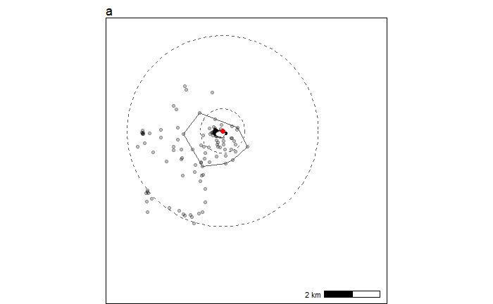

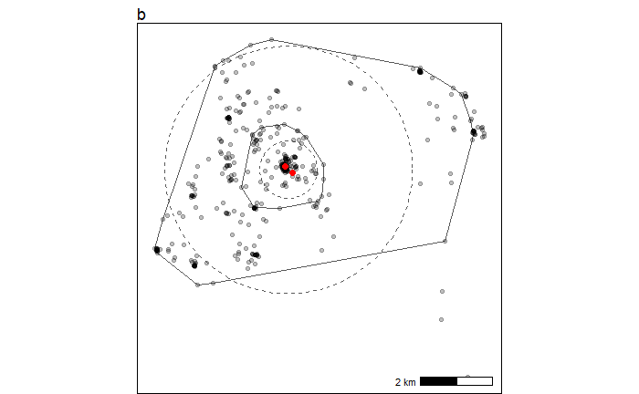

My results, though preliminary, show several interesting patterns and offer promising suggestions for management. The high fidelity of females to the nest area confirms the importance of protected buffers around nests to prevent the disturbance of critical habitat. However, the large distances traveled by males and the irregular shape of their home ranges shows that circular buffers based on estimates of mean home range size are not good approximations of true space use. Home ranges were rarely circular, but rather shaped by geographic constraints such as coastlines or mountains peaks. Within home ranges, kernel density estimates show habitat use is not even across a male’s territory. Instead, there are clusters of activity around areas which are likely high-quality foraging habitat. These areas usually fall outside the nest area and are not be captured by current nesting habitat protections. Goshawks readily crossed narrow barriers such as roads, rivers, and powerline cuts, and sometimes appeared to use these features for travel or foraging. On the other hand, goshawks seemed to generally route around larger barriers such as lakes or clearcuts. This suggests managed areas around nests should be tailored to the amount and configuration of suitable foraging habitat present in the surrounding landscape, and that any timber harvest within the foraging area should prioritize the preservation of connectivity between patches of high-quality foraging habitat. However, a great deal of additional research is needed to confirm and refine these suggestions, particularly regarding the characteristics of suitable and high-quality foraging habitat.

**Management implications**

Climate change is one of the largest and most difficult to anticipate threats facing biodiversity (Bellard et al. 2012). The current understanding of how climate change will impact goshawks in coastal British Columbia is largely speculative (Parks Canada 2018). Although I found no evidence of a link between the degree of dietary specialization and goshawk productivity, the level of specialization I observed and findings from other studies suggest goshawks in my study area are highly dependent on tree squirrels for successful reproduction. Notably, Ethier (1999) found goshawk productivity on Vancouver Island to be significantly correlated with red squirrel abundance. Tree squirrels are themselves highly dependent on conifer seeds and their abundance varies with the size of the annual cone crop. (Smith 1970). Seed production is cyclical, but may be increased by higher temperatures and inhibited by drought (Boucher et al. 2020). As the climate warms and drought risk rises, climate-driven changes in seed production may cascade upward through prey abundance to impact goshawk populations in coastal British Columbia. Significantly more work is needed to understand the relationship between prey abundance, the buffering ability of alternate prey, and goshawk productivity, but my results provide an important starting point for incorporating climate change into goshawk management.